# Intro to R Packages

## Installing & Exploring Packages - seqinr

This notebook was created based on instructions at https://bcb420-2022.github.io/R_basics/r-install.html#task-5---experiment-with-rstudio-and-packages.

### Installing & Loading Packages

```r
library()
```

By running the command above and examining the page that it opens, I see that seqinr is not installed.

```r
search()
```

```
## [1] ".GlobalEnv"        "package:stats"     "package:graphics"
## [4] "package:grDevices" "package:utils"     "package:datasets"
## [7] "package:methods"   "Autoloads"         "package:base"
```

```r
?vignette
```

This opened a help page in the ‘Help’ tab that describes how to view and list vignettes.

```r
?install.packages
if (! requireNamespace("seqinr", quietly=TRUE)) {
  install.packages("seqinr",repos="https://cran.rstudio.com/")
}
```

The above code opened a help page which described how to install new packages. The second command successfully installed seqinr (and will only install it if it is not already installed).

### Listing Functions and Datasets

```r
library(help="seqinr")

library(seqinr)
ls("package:seqinr")
```

```
##   [1] "a"                       "aaa"
##   [3] "AAstat"                  "acnucclose"
##   [5] "acnucopen"               "al2bp"
##   [7] "alllistranks"            "alr"
##   [9] "amb"                     "as.alignment"
##  [11] "as.matrix.alignment"     "as.SeqAcnucWeb"
##  [13] "as.SeqFastaAA"           "as.SeqFastadna"
##  [15] "as.SeqFrag"              "autosocket"
##  [17] "baselineabif"            "bma"
##  [19] "c2s"                     "cai"
##  [21] "cfl"                     "choosebank"
##  [23] "circle"                  "clfcd"
##  [25] "clientid"                "closebank"
##  [27] "col2alpha"               "comp"
##  [29] "computePI"               "con"
```

[output cut: 87 more lines]

The top command opened the vignette for seqinr in a new page. The bottom two commands allowed me to list the 203 functions available in seqinr.

```r
?seqinr::a
seqinr::a("Tyr")
```

```
## [1] "Y"
```

The above commands opened help documentation for the `a` method in `seqinr`. This method converts AA 3-letter codes to 1-letter codes (ex. Tyr -> Y).

```r
seqinr::words(3, c("A", "G", "C", "U"))
```

```
##  [1] "AAA" "AAG" "AAC" "AAU" "AGA" "AGG" "AGC" "AGU" "ACA" "ACG" "ACC" "ACU"
## [13] "AUA" "AUG" "AUC" "AUU" "GAA" "GAG" "GAC" "GAU" "GGA" "GGG" "GGC" "GGU"
## [25] "GCA" "GCG" "GCC" "GCU" "GUA" "GUG" "GUC" "GUU" "CAA" "CAG" "CAC" "CAU"
## [37] "CGA" "CGG" "CGC" "CGU" "CCA" "CCG" "CCC" "CCU" "CUA" "CUG" "CUC" "CUU"
## [49] "UAA" "UAG" "UAC" "UAU" "UGA" "UGG" "UGC" "UGU" "UCA" "UCG" "UCC" "UCU"
## [61] "UUA" "UUG" "UUC" "UUU"
```

The above code produced a vector with all possible 3-letter combinations of “A”, “G”, “C”, and “U”. In other words, it produced all possible RNA codons.

```r
?data
```

According to the help page, the `data` function loads or lists available data sets in a package.

```r
data(package="seqinr")
```

One dataset available in the `seqinr` package is ec999, with has “999 coding sequences from E. coli”.

```r
data(aaindex, package="seqinr")
```

The aaindex dataset lists 544 physicochemical and biological properties for the 20 AAs (ex. conformation parameter of inner helix, average volume of buried residue, melting point, size, etc.).

```r
?aaindex
```

The above command opens the help documentation for the `aaindex` dataset.

```r
aaindex$FASG890101
```

```
## $H
## [1] "FASG890101"
##
## $D
## [1] "Hydrophobicity index (Fasman, 1989)"
##
## $R
## [1] ""
##
## $A
## [1] "Fasman, G.D."
##
## $T
## [1] "Prediction of Protein Structure and the Principles of Protein Conformation"
##
## $J
## [1] "Plenum, New York 1989, page 457, Table XVII"
##
## $C
## [1] "MIYS990105    0.959  MIYS990103    0.957  MEIH800102    0.951MIYS990104    0.949  RACS770102    0.935  GUYH850101    0.934MIYS990102    0.929  MIYS990101    0.926  MEIH800101    0.919KRIW790101    0.914  GUYH850102    0.909  VINM940101    0.904KRIW790102    0.882  GUYH850104    0.872  RACS77…
##
## $I
##   Ala   Arg   Asn   Asp   Cys   Gln   Glu   Gly   His   Ile   Leu   Lys   Met
## -0.21  2.11  0.96  1.36 -6.04  1.52  2.30  0.00 -1.23 -4.81 -4.68  3.88 -3.66
##   Phe   Pro   Ser   Thr   Trp   Tyr   Val
## -4.65  0.75  1.74  0.78 -3.32 -1.01 -3.50
```

```r
aaindex$PONJ960101
```

```
## $H
## [1] "PONJ960101"
##
## $D
## [1] "Average volumes of residues (Pontius et al., 1996)"
##
## $R
## [1] "PMID: 8950272"
##
## $A
## [1] "Pontius, J., Richelle, J. and Wodak, S.J."
##
## $T
## [1] "Deviations from standard atomic volumes as a quality measure for protein crystal structures"
##
## $J
## [1] "J. Mol. Biol 264, 121-136 (1996) (Disulfide bonded cysteine, 102.4)"
##
## $C
## [1] "HARY940101    0.989  CHOC750101    0.966  FAUJ880103    0.963TSAJ990102    0.962  CHOC760101    0.961  TSAJ990101    0.960BIGC670101    0.950  GOLD730102    0.947  FASG760101    0.945KRIW790103    0.943  CHAM820101    0.938  GRAR740103    0.937LEVM760102    0.930  LEVM760105    0.928  CHAM83…
##
## $I
##   Ala   Arg   Asn   Asp   Cys   Gln   Glu   Gly   His   Ile   Leu   Lys   Met
##  91.5 196.1 138.3 135.2 114.4 156.4 154.6  67.5 163.2 162.6 163.4 162.5 165.9
##   Phe   Pro   Ser   Thr   Trp   Tyr   Val
## 198.8 123.4 102.0 126.0 209.8 237.2 138.4
```

FASG890101 and PONJ960101 are the accession numbers of two properties (of the 544) in the `aaindex` db. The first property describes hydrophobicity of the AAs, and the second property describes the average volumes of the AAs.

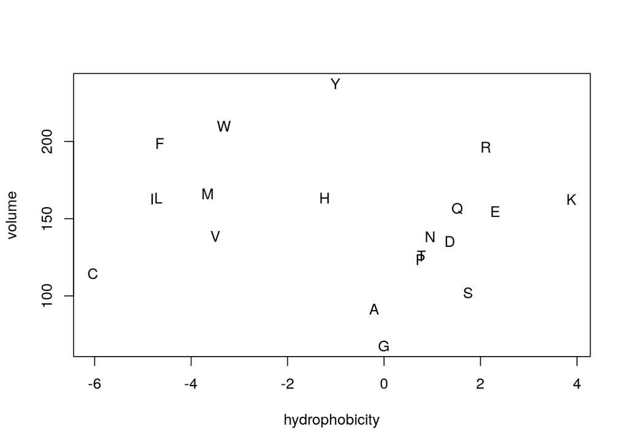

```r
plot(aaindex$FASG890101$I,
     aaindex$PONJ960101$I,
     xlab="hydrophobicity", ylab="volume", type="n")
text(aaindex$FASG890101$I,
     aaindex$PONJ960101$I,
     labels=a(names(aaindex$FASG890101$I)))
```

This command plots the hydrophobicity vs. the volume of each AA.

```r
seqinr::choosebank("swissprot")
mySeq <- seqinr::query("mySeq", "N=MBP1_YEAST")
mbp1 <- seqinr::getSequence(mySeq)
seqinr::closebank()
x <- seqinr::AAstat(mbp1[[1]])
```

[figure not shown]

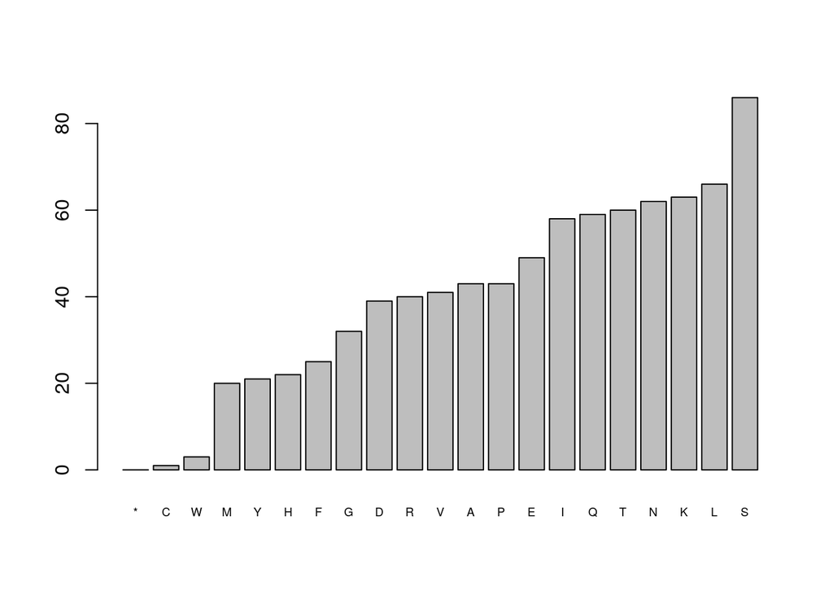

```r
barplot(sort(x$Compo), cex.names = 0.6)
```

This code block fetches the MBP1_YEAST sequence from the swissprot databank, and then plots some statistics about the AAs found in the sequence.

## Finding Packages – sos

```r
if (! requireNamespace("sos", quietly=TRUE)) {
    install.packages("sos")
}
library(help = sos)       # basic information
browseVignettes("sos")    # available vignettes
```

```
## starting httpd help server ...
```

```
##  done
```

```r
sos::findFn("moving average")
```

```
## found 300 matches;  retrieving 15 pages
## 2 3 4 5 6 7 8 9 10
## 11 12 13 14 15
## Downloaded 300 links in 172 packages.
```

| Count | MaxScore | TotalScore | pkgLink | Package | Function | Date | Score | Description | Link |
| --- | --- | --- | --- | --- | --- | --- | --- | --- | --- |
| 16 | 49 | 338 | https://search.r-project.org/CRAN/refmans/TTR/html/00Index.html | TTR | GMMA | 2022-02-04 10:29:09 | 49 | R: Guppy Multiple Moving Averages | https://search.r-project.org/CRAN/refmans/TTR/html/GMMA.html |
| 16 | 49 | 338 | https://search.r-project.org/CRAN/refmans/TTR/html/00Index.html | TTR | MovingAverages | 2022-02-04 10:29:09 | 43 | R: Moving Averages | https://search.r-project.org/CRAN/refmans/TTR/html/MovingAverages.html |
| 16 | 49 | 338 | https://search.r-project.org/CRAN/refmans/TTR/html/00Index.html | TTR | ATR | 2022-02-04 10:29:09 | 30 | R: True Range / Average True Range | https://search.r-project.org/CRAN/refmans/TTR/html/ATR.html |
| 16 | 49 | 338 | https://search.r-project.org/CRAN/refmans/TTR/html/00Index.html | TTR | 00Index | 2022-02-04 10:29:08 | 20 | R: Technical Trading Rules | https://search.r-project.org/CRAN/refmans/TTR/html/00Index.html |
| 16 | 49 | 338 | https://search.r-project.org/CRAN/refmans/TTR/html/00Index.html | TTR | DPO | 2022-02-04 10:29:09 | 19 | R: De-Trended Price Oscillator | https://search.r-project.org/CRAN/refmans/TTR/html/DPO.html |
| 16 | 49 | 338 | https://search.r-project.org/CRAN/refmans/TTR/html/00Index.html | TTR | bollingerBands | 2022-02-04 10:29:09 | 18 | R: Bollinger Bands | https://search.r-project.org/CRAN/refmans/TTR/html/bollingerBands.html |
| 16 | 49 | 338 | https://search.r-project.org/CRAN/refmans/TTR/html/00Index.html | TTR | keltnerChannels | 2022-02-04 10:29:09 | 18 | R: Keltner Channels | https://search.r-project.org/CRAN/refmans/TTR/html/keltnerChannels.html |
| 16 | 49 | 338 | https://search.r-project.org/CRAN/refmans/TTR/html/00Index.html | TTR | MACD | 2022-02-04 10:29:09 | 18 | R: MACD Oscillator | https://search.r-project.org/CRAN/refmans/TTR/html/MACD.html |
| 16 | 49 | 338 | https://search.r-project.org/CRAN/refmans/TTR/html/00Index.html | TTR | TRIX | 2022-02-04 10:29:09 | 17 | R: Triple Smoothed Exponential Oscillator | https://search.r-project.org/CRAN/refmans/TTR/html/TRIX.html |
| 16 | 49 | 338 | https://search.r-project.org/CRAN/refmans/TTR/html/00Index.html | TTR | EMV | 2022-02-04 10:29:09 | 16 | R: Arms' Ease of Movement Value | https://search.r-project.org/CRAN/refmans/TTR/html/EMV.html |

[output cut: 290 more lines]

Other resources for finding packages are the CRAN Task View, Bioconductor Views, Metacran, MRAN, and Google.

## Self-Evaluation

1. The purpose of wrapping an `install.packages` command inside a `requireNamespace` conditional block is to ensure that the package is only installed if it is not already installed. This prevents RStudio from time-consuming and unnecessary installations.